# Full_Code_AIML_USL_Project_CreditCardCustomerSegmentation_CMP

## Problem Statement

### Context

AllLife Bank wants to focus on its credit card customer base in the next financial year. They have been advised by their marketing research team, that the penetration in the market can be improved. Based on this input, the Marketing team proposes to run personalized campaigns to target new customers as well as upsell to existing customers. Another insight from the market research was that the customers perceive the support services of the back poorly. Based on this, the Operations team wants to upgrade the service delivery model, to ensure that customer queries are resolved faster. Head of Marketing and Head of Delivery both decide to reach out to the Data Science team for help

### Objective

To identify different segments in the existing customer, based on their spending patterns as well as past interaction with the bank, using clustering algorithms, and provide recommendations to the bank on how to better market to and service these customers.

### Data Description

The data provided is of various customers of a bank and their financial attributes like credit limit, the total number of credit cards the customer has, and different channels through which customers have contacted the bank for any queries (including visiting the bank, online and through a call center).

**Data Dictionary**

- Sl_No: Primary key of the records
- Customer Key: Customer identification number
- Average Credit Limit: Average credit limit of each customer for all credit cards
- Total credit cards: Total number of credit cards possessed by the customer
- Total visits bank: Total number of Visits that customer made (yearly) personally to the bank
- Total visits online: Total number of visits or online logins made by the customer (yearly)
- Total calls made: Total number of calls made by the customer to the bank or its customer service department (yearly)

## Importing necessary libraries and data

```python
#Libraries to help with reading and manipulatin data
import numpy as np
import pandas as pd

# Libraries to help with data visulaization
import matplotlib.pyplot as plt
import seaborn as sns

# Removes the limit for the number of displayed columns
pd.set_option("display.max_columns",None)
# Sets the limit for the number of displayed rows
pd.set_option("display.max_rows",200)

# to scale the data using z-score
from sklearn.preprocessing import StandardScaler

# to compute distances
from scipy.spatial.distance import pdist

# to perform hierarchical clustering, compute cophenetic correlation, and create dendrograms
from sklearn.cluster import AgglomerativeClustering
from scipy.cluster.hierarchy import dendrogram, linkage, cophenet

# to perform PCA
from sklearn.decomposition import PCA

import seaborn as sns
from sklearn.model_selection import train_test_split
from sklearn.cluster import KMeans

from scipy.stats import zscore

# to suppress warnings
import warnings

warnings.filterwarnings("ignore")
```

# Reading the dataset

```python
from google.colab import drive
drive.mount("/content/drive")
```

```python
data = pd.read_csv("/content/drive/MyDrive/Machine Learning/Credit+Card+Customer+Data.csv")
```

```python
# viewing a random sample of the dataset
data.sample(n=10, random_state=1)
```

|  | Sl_No | Customer Key | Avg_Credit_Limit | Total_Credit_Cards | Total_visits_bank | Total_visits_online | Total_calls_made |
| --- | --- | --- | --- | --- | --- | --- | --- |
| 547 | 548 | 38125 | 26000 | 4 | 5 | 2 | 4 |
| 353 | 354 | 94437 | 9000 | 5 | 4 | 1 | 3 |
| 499 | 500 | 65825 | 68000 | 6 | 4 | 2 | 2 |
| 173 | 174 | 38410 | 9000 | 2 | 1 | 5 | 8 |
| 241 | 242 | 81878 | 10000 | 4 | 5 | 1 | 3 |
| 341 | 342 | 70779 | 18000 | 4 | 3 | 2 | 0 |
| 647 | 648 | 79953 | 183000 | 9 | 0 | 9 | 2 |
| 218 | 219 | 28208 | 19000 | 3 | 1 | 5 | 7 |
| 120 | 121 | 16577 | 10000 | 4 | 2 | 4 | 6 |
| 134 | 135 | 31256 | 13000 | 4 | 1 | 5 | 7 |

# Checking the shape of the dataset

```python
data.shape
```

```
(660, 7)
```

- The dataset has 660 rows and 7 columns

```python
# Copying the data to another variable to avoid any changes to the original data
df1 = data.copy()
```

```python
# checking for missing values

df1.isnull().sum()
```

```
Sl_No                  0
Customer Key           0
Avg_Credit_Limit       0
Total_Credit_Cards     0
Total_visits_bank      0
Total_visits_online    0
Total_calls_made       0
dtype: int64
```

# Check the data types of the columns for the dataset

```python
# Checking the datatypes and number of non-null values for each column
df1.info()
```

```
<class 'pandas.core.frame.DataFrame'>
RangeIndex: 660 entries, 0 to 659
Data columns (total 7 columns):
 #   Column               Non-Null Count  Dtype
---  ------               --------------  -----
 0   Sl_No                660 non-null    int64
 1   Customer Key         660 non-null    int64
 2   Avg_Credit_Limit     660 non-null    int64
 3   Total_Credit_Cards   660 non-null    int64
 4   Total_visits_bank    660 non-null    int64
 5   Total_visits_online  660 non-null    int64
 6   Total_calls_made     660 non-null    int64
dtypes: int64(7)
memory usage: 36.2 KB
```

**Observations**

- All the variables are numeric variables and there is no string or object variables
- There are no missing value in any of the columns

# Summary of the dataset

```python
# Let's look at the statiscal summary of the data
df1.describe(include="all").T
```

|  | count | mean | std | min | 25% | 50% | 75% | max |
| --- | --- | --- | --- | --- | --- | --- | --- | --- |
| Sl_No | 660.0 | 330.500000 | 190.669872 | 1.0 | 165.75 | 330.5 | 495.25 | 660.0 |
| Customer Key | 660.0 | 55141.443939 | 25627.772200 | 11265.0 | 33825.25 | 53874.5 | 77202.50 | 99843.0 |
| Avg_Credit_Limit | 660.0 | 34574.242424 | 37625.487804 | 3000.0 | 10000.00 | 18000.0 | 48000.00 | 200000.0 |
| Total_Credit_Cards | 660.0 | 4.706061 | 2.167835 | 1.0 | 3.00 | 5.0 | 6.00 | 10.0 |
| Total_visits_bank | 660.0 | 2.403030 | 1.631813 | 0.0 | 1.00 | 2.0 | 4.00 | 5.0 |
| Total_visits_online | 660.0 | 2.606061 | 2.935724 | 0.0 | 1.00 | 2.0 | 4.00 | 15.0 |
| Total_calls_made | 660.0 | 3.583333 | 2.865317 | 0.0 | 1.00 | 3.0 | 5.00 | 10.0 |

**Observations**

- Avergage credit limit is 34.5K
- Average number of credict cards per customer is 4.7
- Some users never visited the bank and the average visit by customers is 2.4
- Some customers visited or accessed the bank via online. Average visit to the onsite by customers is 2.6
- Also, some customers never made any calls to the bank. Average call made by customers are 3.58

**We won't need Sl_No and Customer key, so let's drop this column**

```python
#sl_no and customer key is unique for each record and does not provide any value. Let us go ahead and drop them
df1.drop(["Sl_No",'Customer Key'],axis=1, inplace=True)
```

**Let us check how much percentage of the customer did not made**

- Visits to the bank
- Online visits
- Calls made

```python
df1['Total_visits_bank'].value_counts(normalize=True) * 100
```

```
2    23.939394
1    16.969697
0    15.151515
3    15.151515
5    14.848485
4    13.939394
Name: Total_visits_bank, dtype: float64
```

```python
df1['Total_visits_online'].value_counts(normalize=True) * 100
```

```
2     28.636364
0     21.818182
1     16.515152
4     10.454545
5      8.181818
3      6.666667
15     1.515152
7      1.060606
10     0.909091
12     0.909091
8      0.909091
11     0.757576
13     0.757576
9      0.606061
14     0.151515
6      0.151515
Name: Total_visits_online, dtype: float64
```

```python
df1['Total_calls_made'].value_counts(normalize=True) * 100
```

```
4     16.363636
0     14.696970
2     13.787879
1     13.636364
3     12.575758
6      5.909091
7      5.303030
9      4.848485
8      4.545455
5      4.393939
10     3.939394
Name: Total_calls_made, dtype: float64
```

**Duplicate value check**

```python
# let's check for duplicate observations
df1.duplicated().sum()
```

```
11
```

- There are 11 duplicate observations. We will remove them from the data

```python
df1 = df1[(~df1.duplicated())].copy()
```

# Univariate Analysis

```python
# function to plot a boxplot and histogram along the same scale
def histogram_boxplot(data, feature, figsize=(12,7), kde=False, bins=None):
  f2,(ax_box2, ax_hist2) = plt.subplots(
      nrows=2,
      sharex=True,
      gridspec_kw={"height_ratios": (0.25, 0.75)},
      figsize=figsize,
  )
  sns.boxplot(
      data=data, x=feature, ax=ax_box2, showmeans=True, color='violet'
  )
  sns.histplot(
      data=data,x=feature,kde=kde,ax=ax_hist2, bins=bins,palette='winter'
  ) if bins else sns.histplot(
      data=data, x=feature,kde=kde, ax=ax_hist2
  )
  ax_hist2.axvline(
      data[feature].mean(),color='green',linestyle="--"
  )
  ax_hist2.axvline(
      data[feature].median(), color='black',linestyle="-"
  )
```

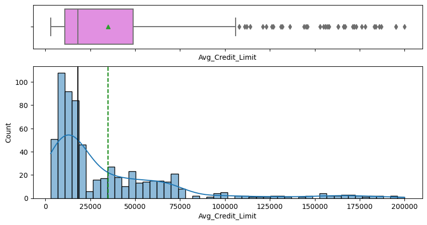

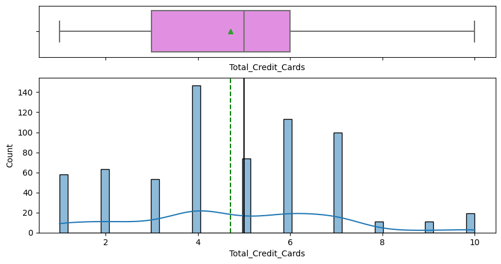

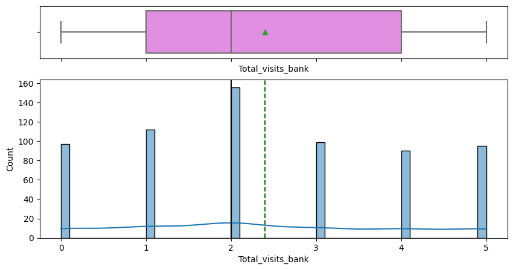

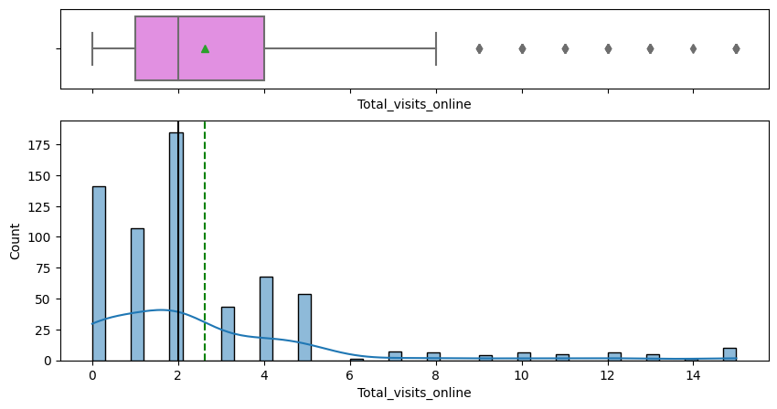

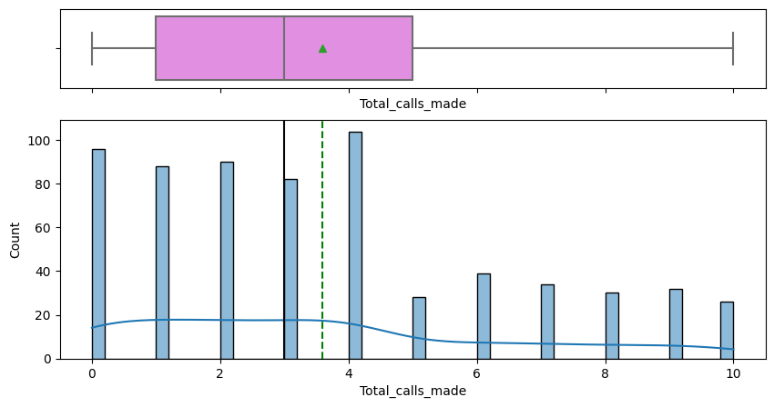

```python
# selecting numerical columns
num_cols = df1.select_dtypes(include=np.number).columns.tolist()

for item in num_cols:
  histogram_boxplot(df1,item,  figsize=(10,5), kde =True, bins=50)
```

# Bivariate Analysis

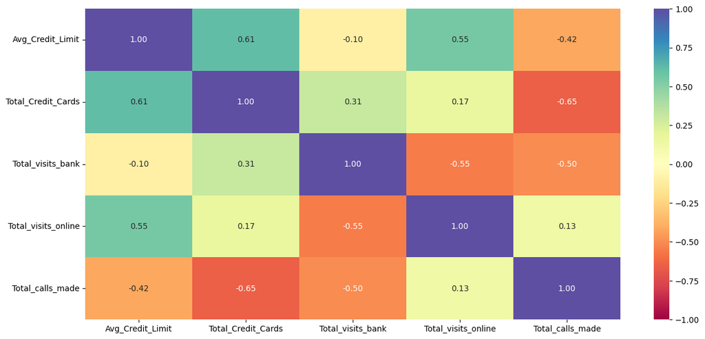

```python
plt.figure(figsize=(15,7))
sns.heatmap(
    df1[num_cols].corr(),annot=True, vmin=-1,vmax=1,fmt=".2f",cmap="Spectral"
)
plt.show()
```

**Observations**

- Total credit cards and Average credit limit is positively correlatd
- Total credit cards and Total call made or negatively correlated

## Exploratory Data Analysis (EDA)

- EDA is an important part of any project involving data.
- It is important to investigate and understand the data better before building a model with it.
- A few questions have been mentioned below which will help you approach the analysis in the right manner and generate insights from the data.
- A thorough analysis of the data, in addition to the questions mentioned below, should be done.

### Questions

:1. How is the distrubution of average credit limit of customer? Average credit limit of the customers is 34574, min is 3000 and maximum is 200K

1. What percenatage of the customers have never made a service-related call to the bank? 15% of the customer never made a service related to the call
2. What percentage of customers have never logged in to the online portal? 22% percent of customers never logged into the online portal
3. How many customers have never visited bank? 15% of customers never visited the bank
4. How are the different variables correlated with each other?
- Number of credit cards and average credit limit is positively correlated.
- Total credit cards and Total call made are negatively correlated.

## Data Preprocessing

- Duplicate value check
- Missing value treatment
- Outlier check
- Feature engineering (if needed)
- Any other preprocessing steps (if needed)

## EDA

- It is a good idea to explore the data once again after manipulating it.

## K-means Clustering

```python
df1_kmeans = df1.copy()
```

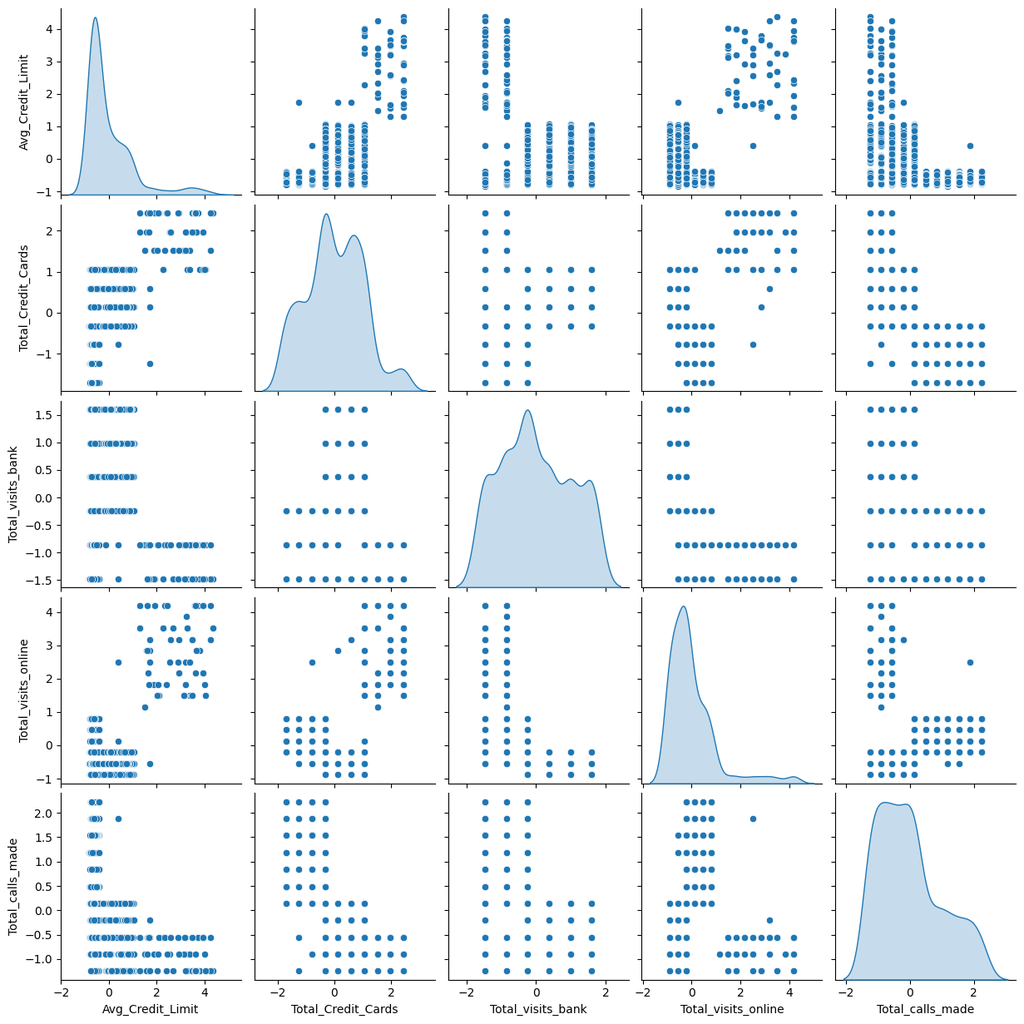

```python
# Apply the zscore to get the scaled data
df1_kmeansAttr = df1_kmeans.iloc[:,0:]
df1_kmeansScaled= df1_kmeansAttr.apply(zscore)
sns.pairplot(df1_kmeansScaled,diag_kind='kde')
```

**Observations:**

- More service calls came from the customers whose credit limit is less than average
- Higher the credit limit, customers use more number of credit cards
- Higher credit limit customers did the most banking online

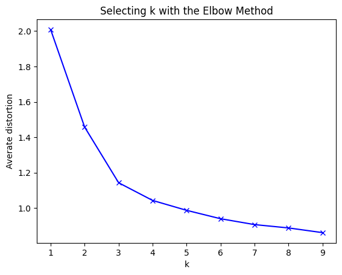

```python
#Finding optimal no. of clusters
from scipy.spatial.distance import cdist
clusters=range(1,10)
meanDistortions=[]

for k in clusters:
  model = KMeans(n_clusters=k)
  model.fit(df1_kmeansScaled)
  prediction= model.predict(df1_kmeansScaled)
  meanDistortions.append(sum(np.min(cdist(df1_kmeansScaled,model.cluster_centers_,'euclidean'),axis=1))/df1_kmeansScaled.shape[0])

plt.plot(clusters,meanDistortions,'bx-')
plt.xlabel('k')
plt.ylabel('Averate distortion')
plt.title("Selecting k with the Elbow Method")
```

```python
#Let us  start with K=5
final_model=KMeans(5)
final_model.fit(df1_kmeansScaled)
prediction= final_model.predict(df1_kmeansScaled)

#Append the prediction
df1_kmeans["Group"]= prediction
df1_kmeansScaled["Group"] = prediction
print('Groups Assinged : \n')
df1_kmeans.head()
```

```
Groups Assinged :
```

|  | Avg_Credit_Limit | Total_Credit_Cards | Total_visits_bank | Total_visits_online | Total_calls_made | Group |
| --- | --- | --- | --- | --- | --- | --- |
| 0 | 100000 | 2 | 1 | 1 | 0 | 0 |
| 1 | 50000 | 3 | 0 | 10 | 9 | 1 |
| 2 | 50000 | 7 | 1 | 3 | 4 | 0 |
| 3 | 30000 | 5 | 1 | 1 | 4 | 0 |
| 4 | 100000 | 6 | 0 | 12 | 3 | 2 |

```python
df1_kmeansScaled.head()
```

|  | Avg_Credit_Limit | Total_Credit_Cards | Total_visits_bank | Total_visits_online | Total_calls_made | Group |
| --- | --- | --- | --- | --- | --- | --- |
| 0 | 1.723499 | -1.247087 | -0.860606 | -0.550407 | -1.248443 | 0 |
| 1 | 0.400209 | -0.786701 | -1.476410 | 2.499808 | 1.881237 | 1 |
| 2 | 0.400209 | 1.054846 | -0.860606 | 0.127419 | 0.142526 | 0 |
| 3 | -0.129107 | 0.134072 | -0.860606 | -0.550407 | 0.142526 | 0 |
| 4 | 1.723499 | 0.594459 | -1.476410 | 3.177634 | -0.205216 | 2 |

```python
df1_kmeansScaledClust = df1_kmeansScaled.groupby(['Group'])
df1_kmeansScaledClust.mean()
```

| Group | Avg_Credit_Limit | Total_Credit_Cards | Total_visits_bank | Total_visits_online | Total_calls_made |
| --- | --- | --- | --- | --- | --- |
| 0 | 0.035447 | 0.389313 | 0.061503 | -0.564455 | -0.538544 |
| 1 | -0.589047 | -1.077236 | -0.998116 | 0.377490 | 1.766449 |
| 2 | 2.809656 | 1.855918 | -1.106928 | 2.804830 | -0.872881 |
| 3 | -0.607959 | -1.040303 | -0.803201 | 0.265281 | 0.608147 |
| 4 | -0.080611 | 0.355556 | 1.303027 | -0.548575 | -0.573635 |

```
array([[<Axes: title={'center': 'Avg_Credit_Limit'}, xlabel='[Group]'>,
        <Axes: title={'center': 'Total_Credit_Cards'}, xlabel='[Group]'>,
        <Axes: title={'center': 'Total_calls_made'}, xlabel='[Group]'>,
        <Axes: title={'center': 'Total_visits_bank'}, xlabel='[Group]'>],
       [<Axes: title={'center': 'Total_visits_online'}, xlabel='[Group]'>,
        <Axes: >, <Axes: >, <Axes: >]], dtype=object)
```

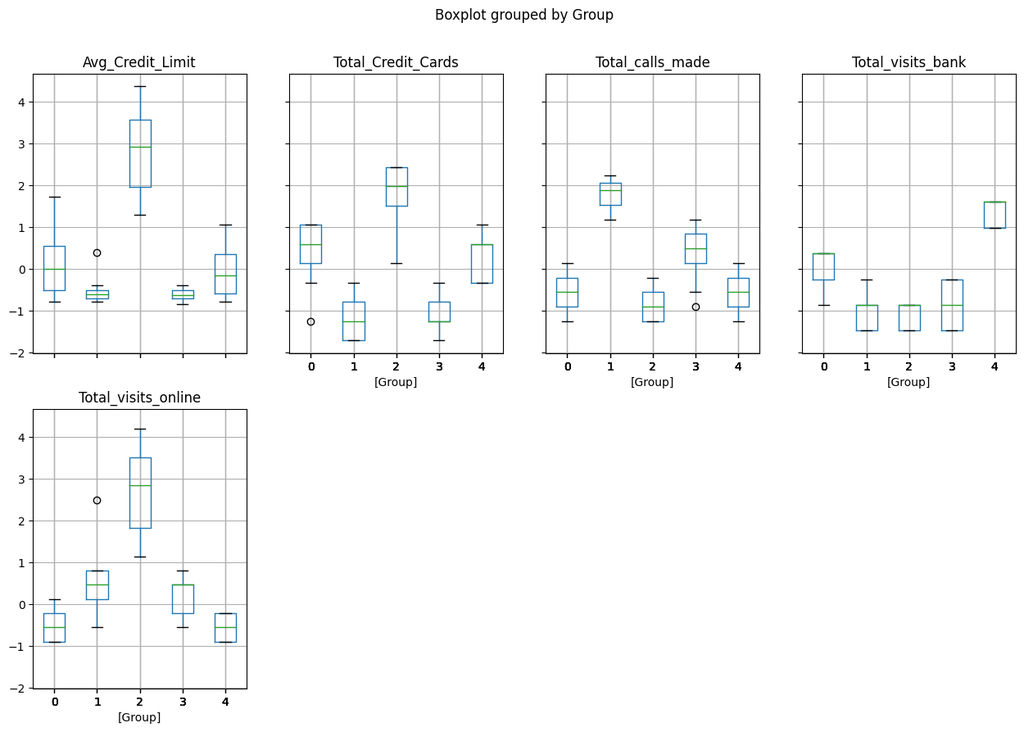

```python
df1_kmeansScaled.boxplot(by="Group",layout=(2,4),figsize=(15,10))
```

**Cluster 0**

**Cluster 1**

**Cluster 2**

**Cluster 3**

**Cluster 4**

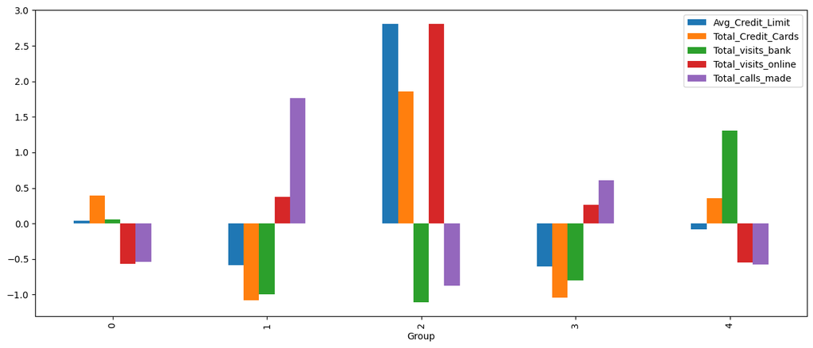

```python
df1_kmeansScaled.groupby("Group").mean().plot.bar(figsize=(15, 6))
```

## Hierarchical Clustering

```python
sc = StandardScaler()
df_scaled_df = pd.DataFrame(
    sc.fit_transform(df1),
    columns=df1.columns
)
df_scaled_df.head()
```

|  | Avg_Credit_Limit | Total_Credit_Cards | Total_visits_bank | Total_visits_online | Total_calls_made |
| --- | --- | --- | --- | --- | --- |
| 0 | 1.723499 | -1.247087 | -0.860606 | -0.550407 | -1.248443 |
| 1 | 0.400209 | -0.786701 | -1.476410 | 2.499808 | 1.881237 |
| 2 | 0.400209 | 1.054846 | -0.860606 | 0.127419 | 0.142526 |
| 3 | -0.129107 | 0.134072 | -0.860606 | -0.550407 | 0.142526 |
| 4 | 1.723499 | 0.594459 | -1.476410 | 3.177634 | -0.205216 |

```python
from scipy.spatial import distance
# list of distance metrics
distance_metrics=["euclidean","chebyshev","mahalanobis","cityblock"]

# list of linkage methods
linkage_methods = ["single","complete","average","weighted"]

high_cophenet_corr = 0
high_dm_lm = [0,0]

for dm in distance_metrics:
  for lm in linkage_methods:
    Z = linkage(df_scaled_df, metric=dm, method=lm)
    c,coph_dists = cophenet(Z, pdist(df_scaled_df))
    print (
        "Cophenetic correlation for {} distance and {} linkage is {}.".format(
            dm.capitalize(),lm,c

        )
    )
    if high_cophenet_corr < c:
      high_cophenet_corr=c
      high_dm_lm[0]=dm
      high_dm_lm[1]= lm
```

```
Cophenetic correlation for Euclidean distance and single linkage is 0.7395135051413775.
Cophenetic correlation for Euclidean distance and complete linkage is 0.8794736468795109.
Cophenetic correlation for Euclidean distance and average linkage is 0.8974425535306298.
Cophenetic correlation for Euclidean distance and weighted linkage is 0.8551098644586315.
Cophenetic correlation for Chebyshev distance and single linkage is 0.7379112982920528.
Cophenetic correlation for Chebyshev distance and complete linkage is 0.8578617029322211.
Cophenetic correlation for Chebyshev distance and average linkage is 0.8960370054789858.
Cophenetic correlation for Chebyshev distance and weighted linkage is 0.893309534644998.
Cophenetic correlation for Mahalanobis distance and single linkage is 0.7054746377393306.
Cophenetic correlation for Mahalanobis distance and complete linkage is 0.6165028065519289.
Cophenetic correlation for Mahalanobis distance and average linkage is 0.8325710192720918.
Cophenetic correlation for Mahalanobis distance and weighted linkage is 0.7739344020426618.
Cophenetic correlation for Cityblock distance and single linkage is 0.7253931237436752.
Cophenetic correlation for Cityblock distance and complete linkage is 0.8741048470104825.
Cophenetic correlation for Cityblock distance and average linkage is 0.8960391624288154.
Cophenetic correlation for Cityblock distance and weighted linkage is 0.8804995247359442.
```

```python
# Printing the combination of distance metric and linkage method with the highest cophenetic correlation
print(
    "Highest cophenetic correlatio is {}, which is obtained with {} distance and {} linkage.".format(
        high_cophenet_corr, high_dm_lm[0].capitalize(), high_dm_lm[1]
)
)
```

```
Highest cophenetic correlatio is 0.8974425535306298, which is obtained with Euclidean distance and average linkage.
```

```python
#list of linkage methods
linkage_methods =["single","complete","average","centroid","ward","weighted"]

high_cophenet_corr = 0
high_dm_lm = [0,0]

for lm in linkage_methods:
  Z = linkage(df_scaled_df,metric="euclidean",method=lm)
  c, coph_dists = cophenet(Z, pdist(df_scaled_df))
  print('Cophenetic correlation for {} linkage is {}.'.format(lm,c))
  if high_cophenet_corr < c:
    high_cophenet_corr =c
    high_dm_lm[0] = "euclidean"
    high_dm_lm[1] = lm
```

```
Cophenetic correlation for single linkage is 0.7395135051413775.
Cophenetic correlation for complete linkage is 0.8794736468795109.
Cophenetic correlation for average linkage is 0.8974425535306298.
Cophenetic correlation for centroid linkage is 0.894471288720818.
Cophenetic correlation for ward linkage is 0.7425813590948763.
Cophenetic correlation for weighted linkage is 0.8551098644586315.
```

```python
# printing the combination of distance metric and linkage method with the highest cophenetic correlation
print(
    "Highest cophenetic corelation is {}, which is obtained with {} linkage.".format(
        high_cophenet_corr,high_dm_lm[1]
    )
)
```

```
Highest cophenetic corelation is 0.8974425535306298, which is obtained with average linkage.
```

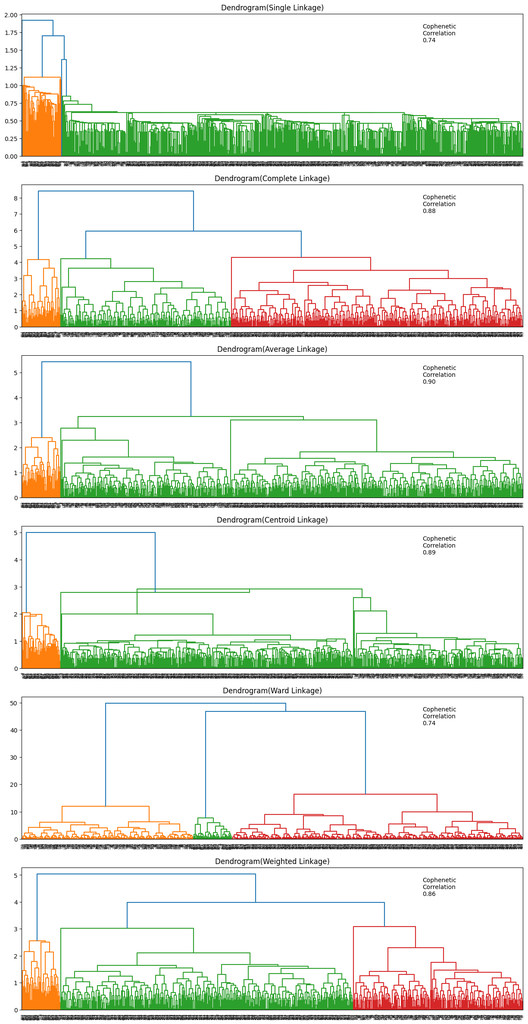

```python
# list of linkage methods
linkage_methods = ["single","complete","average","centroid","ward","weighted"]

#lists to save results of cophenetic correlation coefficient
compare_cols = ["Linkage","Cophenetic Coefficient"]

fig,axs = plt.subplots(len(linkage_methods),1,figsize=(15,30))

# We wil enumerate through the list of linkage methods above
# For each linkage method, we will plot the dendrogram and calcuate teh cophenetic correlation
for i, method in enumerate(linkage_methods):
  Z= linkage(df_scaled_df,metric="euclidean",method=method)

  dendrogram(Z, ax=axs[i])
  axs[i].set_title(f"Dendrogram({method.capitalize()} Linkage)")

  coph_corr, coph_dist = cophenet(Z, pdist(df_scaled_df))
  axs[i].annotate(
      f"Cophenetic\nCorrelation\n{coph_corr:0.2f}",
      (0.80,0.80),
      xycoords="axes fraction"
  )
```

**Observations**

- The cophenetic correlation is highest for average and centroid linkage methods
- We will move ahead with Average linkage
- 5 appears to be the appropriate number of clusters from the dendrogram for Average linkage

**Lets visualize the dendrogram cut for average link in the below plot**

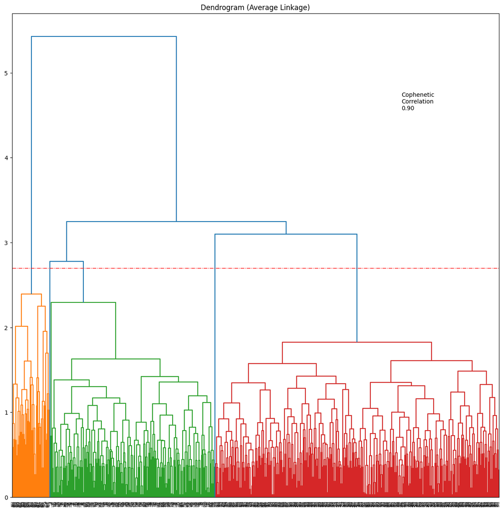

```python
# list of linkage methods
linkage_methods = ["average"]

# lists to save results of cophenetic correlation calculation
compare_cols = ["Linkage", "Cophenetic Coefficient"]

# to create a subplot image
fig, axs = plt.subplots(len(linkage_methods), 1, figsize=(15, 15))

# We will enumerate through the list of linkage methods above
# For each linkage method, we will plot the dendrogram and calculate the cophenetic correlation
for i, method in enumerate(linkage_methods):
    Z = linkage(df_scaled_df, metric="euclidean", method=method)

    dendrogram(Z, ax=axs)
    axs.set_title(f"Dendrogram ({method.capitalize()} Linkage)")

    coph_corr, coph_dist = cophenet(Z, pdist(df_scaled_df))
    axs.annotate(
        f"Cophenetic\nCorrelation\n{coph_corr:0.2f}",
        (0.80, 0.80),
        xycoords="axes fraction",
    )
dendrogram(Z, color_threshold=2.7)
plt.axhline(y=2.7, c="red", lw=1, linestyle="dashdot")
```

```python
HCmodel = AgglomerativeClustering(n_clusters=5, affinity="euclidean", linkage="average")
HCmodel.fit(df_scaled_df)
```

```
AgglomerativeClustering(affinity='euclidean', linkage='average', n_clusters=5)
```

```python
df_scaled_df["HC_Clusters"] = HCmodel.labels_
df1["HC_Clusters"] = HCmodel.labels_
```

## Cluster Profiling and Comparison

```python
cluster_profile = df1.groupby("HC_Clusters").mean()
```

**Lets visualize the dendrogram cut for ward linkage in the below plot**

[figure not shown]

```python
# list of linkage methods
linkage_methods = ["ward"]

# lists to save results of cophenetic correlation calculation
compare_cols = ["Linkage", "Cophenetic Coefficient"]

# to create a subplot image
fig, axs = plt.subplots(len(linkage_methods), 1, figsize=(15, 15))

# We will enumerate through the list of linkage methods above
# For each linkage method, we will plot the dendrogram and calculate the cophenetic correlation
for i, method in enumerate(linkage_methods):
    Z = linkage(df_scaled_df, metric="euclidean", method=method)

    dendrogram(Z, ax=axs)
    axs.set_title(f"Dendrogram ({method.capitalize()} Linkage)")

    coph_corr, coph_dist = cophenet(Z, pdist(df_scaled_df))
    axs.annotate(
        f"Cophenetic\nCorrelation\n{coph_corr:0.2f}",
        (0.80, 0.80),
        xycoords="axes fraction",
    )
dendrogram(Z, color_threshold=15.5)
plt.axhline(y=15.5, c="red", lw=1, linestyle="dashdot")
```

```python
HCmodel = AgglomerativeClustering(n_clusters=5, affinity="euclidean", linkage="ward")
HCmodel.fit(df_scaled_df)
```

```
AgglomerativeClustering(affinity='euclidean', n_clusters=5)
```

```python
df_scaled_df["HC_Clusters"] = HCmodel.labels_
df1["HC_Clusters"] = HCmodel.labels_
```

```python
cluster_profile = df1.groupby("HC_Clusters").mean()
```

```python
cluster_profile["count_in_each_segments"] = (
    df1.groupby('HC_Clusters')['Avg_Credit_Limit'].count().values
)
```

```python
# lets display cluster profile
cluster_profile.style.highlight_max(color="lightgreen", axis=0)
```

| HC_Clusters | Avg_Credit_Limit | Total_Credit_Cards | Total_visits_bank | Total_visits_online | Total_calls_made | count_in_each_segments |
| --- | --- | --- | --- | --- | --- | --- |
| 0 | 37497.409326 | 5.647668 | 2.528497 | 0.979275 | 2.124352 | 193 |
| 1 | 30370.967742 | 5.376344 | 4.467742 | 0.989247 | 1.865591 | 186 |
| 2 | 141040.000000 | 8.740000 | 0.600000 | 10.900000 | 1.080000 | 50 |
| 3 | 12549.019608 | 2.205882 | 0.852941 | 3.705882 | 8.627451 | 102 |
| 4 | 12016.949153 | 2.576271 | 1.016949 | 3.449153 | 5.415254 | 118 |

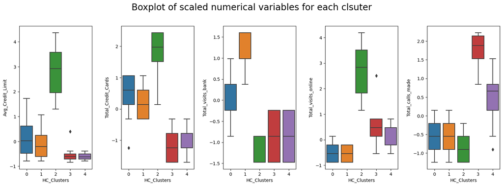

```python
fig, axes = plt.subplots(1,5,figsize=(16,6))
fig.suptitle("Boxplot of scaled numerical variables for each clsuter",fontsize=20)
counter=0
for ii in range(5):
  sns.boxplot(
      ax= axes[ii],
      y=df_scaled_df[num_cols[counter]],
      x=df_scaled_df["HC_Clusters"]
  )
  counter = counter + 1

fig.tight_layout(pad=2.0)
```

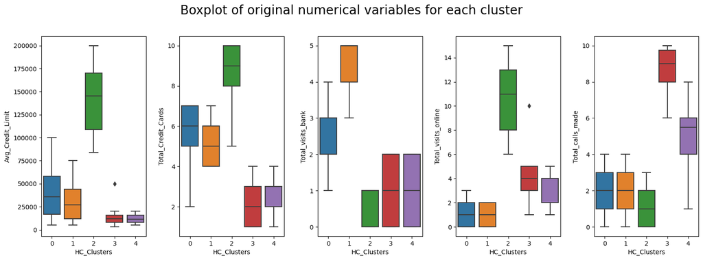

```python
fig, axes = plt.subplots(1,5,figsize=(16,6))
fig.suptitle("Boxplot of original numerical variables for each cluster",fontsize=20)
counter = 0
for ii in range(5):
  sns.boxplot(ax=axes[ii], y=df1[num_cols[counter]],x=df1["HC_Clusters"])
  counter = counter + 1

fig.tight_layout(pad=2.0)
```

# Observations

**Cluster 0**

- Average crdit limit for this grops is in the range of 22000 -55000
- This groups carries 5-7 credit cards which is the second highest
- Number of visits to banks for this groups is 2-3
- Online visits are low and in the range of 1-2
- This group made 1-3 calls per year which is low

**Cluster 1**

- Average crdit limit for this grops is in the range of 12500 -43500
- This groups carries 4-6 credit cards which is the considerable number
- Number of visits to banks for this groups is heighest and in the range of 4-5
- Online visits are low and in the range of 0-2
- This group made 1-3 calls per year which is low

**Cluster 2**

- Average crdit limit for this grops is in the range of 112500 -172500
- This groups carries 8-10 credit cards which is the highest
- Number of visits to banks for this groups is the lowest and in the range 0-1
- Online visits are highest for this group and in the range of 8-13
- This group made 0-2 calls per year which is lowest among the groups

**Cluster 3**

**Cluster 4**

## K-means vs Hierarchical Clustering

You compare several things, like:

- Which clustering technique took less time for execution?
- Which clustering technique gave you more distinct clusters, or are they the same?
- How many observations are there in the similar clusters of both algorithms?
- How many clusters are obtained as the appropriate number of clusters from both algorithms?

You can also mention any differences or similarities you obtained in the cluster profiles from both the clustering techniques.

- K-means clustering is comparatively faster but still the execution times are insignificant for both mehdos as the datset is small
- Both techniques gave distinct 5 clusters
- Most of the observations are similat between both cluster and only minor differences are noticed between the observations in the cluster
- Five clusters are obtained as the appropriate number of clusters from both algorithms
- Both clusters provide almost similar grouping profile